# Parallel computing and futures

*Note: These notes borrow heavily from Alex Reinhart’s lecture notes for [Advanced Statistical Computing from Spring 2019](https://www.refsmmat.com/courses/751/index.html)*

# Computer architecture background

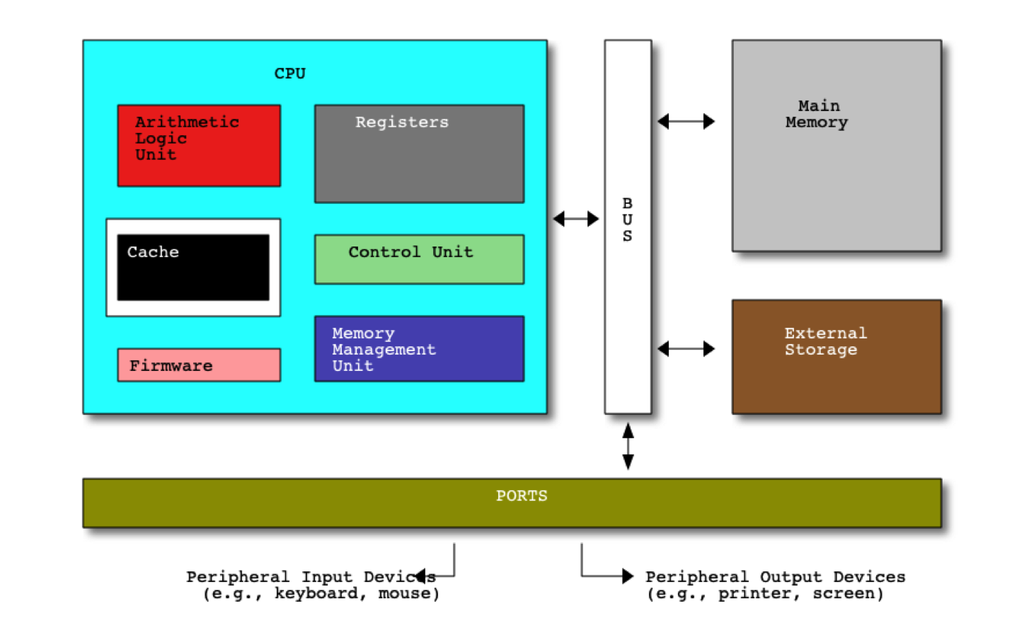

**Main Memory (RAM)**: large, fast, random access storage where each slot in memory has a unique address. But its contents are lost once power is off and can’t be used to store data permanently.

**Bus**: Allows transfer of data between parts of the computer.

**Central Processing Unit (CPU)**: computer’s control center, carries out the instructions given by programs.

- **Registers**: Fast storage used in executing instructions, vary between general and specialized purposes. CPU uses registers to manage control of the program’s flow. In the ideal world we would want all of our data in registers, but that’s not physically possible. Only useful for what you’re operating on **right now** with a particular set of instructions. CPU instructions to request data from RAM to load into registers, but that’s a slow process…
- **Cache**: Small but fast memory unit that is orders of magnitude faster than RAM. When a program loads data from RAM, CPU automatically stores copies of it in the cache to make it available for registers. Processor tracks any modifications to data in cache to then updates RAM copies of data. Cache usage affects performance, e.g., you’ll hit a point when loading a large matrix that data no longer fits in cache and the processor must retrieve it from main main memory.

How a CPU runs a program:

- Takes a starting address that points to the machine code of the program
- Proceeds through the instructions:
  - Modifying registers and memory (plus any interaction with external storage or ports)
  - Keeps track of where it is in the code

Over-simplified summary: CPUs are machines that execute instructions and shuffle data between RAM, cache, and registers.

## Multi-core machines

What happens when we have multiple CPUs in a single machine? (aka a modern computer)

**Symmetric multiprocessing**: multiple CPUs connected to the same bus, with still only one source of main memory but each processor has its own cache. Works well when running multiple tasks, e.g. running a web browser and R simultaneously on two separate processors.

What happens if we have two different processors modifying the same memory at the same time:

1. Processor 1 is working with some data from RAM, so a copy is loaded into its cache.
2. Processor 2 starts working with that same data, so it loads its own copy into its cache.
3. Processor 1 modifies the data on its cache, then writes back to RAM.
4. Processor 2 is stuch with an older version of the data!

This is known as **incoherence** - thus processors must have methods to ensure **cache coherence**, e.g. deleting Processor 2’s cache data when Processor 1 modifies it on RAM forcing Processor 2 to fetch the updated version from RAM the next time it accesses the data.

**This has important implications for speed of parallel programs.**

# Concurrency versus Parallelism

- **Concurrency**: managing multiple tasks that share resources (e.g., data in memory)
  - Challenge is controlling access to shared resources
  - Operating systems enable concurrency through spawning (aka creating) **processes** and **threads**
  - **Process**: basically a program combined with its activity, including data in memory and files currently open. Multiple processes are always concurrent but still isolated from each other (Process 1 cannot interfere with Process 2’s execution), and may run in parallel with several processors
  - **Thread**: Lower level of a process, you can create multiple threads inside a single process where each thread shares memory access. Spawning processes and threads is not free and requires bookkeeping. Concurrency and paralellism frameworks typically create a **thread pool** of ready-to-use threads for tasks to avoid the creation step.
- **Parallelism**: performing many tasks simultaneously

# What the fork

Two core operations for creating processes are `fork` and `exec` (for Unix-like systems). These are **system calls** made by programs to the OS.

- `fork` creates a copy of a process: a *parent* process divides itself (“forks”) into two identical processes, with access to open files, registers, and all memory allocations, including the program’s executable code.
  - New, forked process is called the *child*, has a new process identifier (PID) distinguishing itself
  - Memory is not copied because modern computing uses **copy on write**: both processes use the same memory until one modifies any chunk of memory, it then receives its own personal copy of that chunk.
- `exec` replaces a process with another one… by forking:
  - `fork` the process
  - parent process keeps going
  - child `exec` new program to run, replacing the child with the new program

# Parallel computing

The `parallel` package is built into `R` with the basic parellelized versions of typically used functions such as `mclapply` instead of `lapply`. From Roger Peng’s [`R` Programming for Data Science](https://bookdown.org/rdpeng/rprogdatascience/):

> The mclapply() function (and related mc* functions) works via the fork mechanism on Unix-style operating systems. Briefly, your R session is the main process and when you call a function like mclapply(), you fork a series of sub-processes that operate independently from the main process (although they share a few low-level features). These sub-processes then execute your function on their subsets of the data, presumably on separate cores of your CPU. Once the computation is complete, each sub-process returns its results and then the sub-process is killed. The parallel package manages the logistics of forking the sub-processes and handling them once they’ve finished.

```r
library(parallel)
library(microbenchmark)
# Make a pointless function
foo <- function(n = 1000) mean(rnorm(n))

# Compare the lapply with parallel version:
init_lapply_results <- microbenchmark(
  basic_lapply = {
    lapply_sim_list <- lapply(1:100, foo)
    },
  parallel_mclapply = {
    mclapply_sim_list <- mclapply(1:100, foo, mc.cores = 4)
    },
  times = 100)
init_lapply_results
```

```
Unit: microseconds
```

| expr | min | lq | mean | median | uq | max | neval |
| --- | --- | --- | --- | --- | --- | --- | --- |
| basic_lapply | 698.143 | 737.0455 | 1502.092 | 1414.909 | 1994.258 | 3370.896 | 100 |
| parallel_mclapply | 5755.209 | 7266.7700 | 7972.249 | 8049.521 | 8549.354 | 11563.568 | 100 |

It’s slower but why? Can get a better understanding via `system.time`:

```r
foo_lapply_time <-
  system.time({
         foo_list <- lapply(1:100, foo)
})
foo_lapply_time
```

```
   user  system elapsed
  0.001   0.000   0.000
```

```r
foo_mclapply_time <-
  system.time({
         foo_list <- mclapply(1:100, foo, mc.cores = 4)
})
foo_mclapply_time
```

```
   user  system elapsed
  0.005   0.008   0.007
```

We can check the difference in time `R` spends in the main and the child processes:

```r
foo_mclapply_time["user.self"]
```

```
user.self
    0.001
```

```r
foo_mclapply_time["user.child"]
```

```
user.child
     0.004
```

```r
foo_mclapply_time["sys.self"]
```

```
sys.self
   0.003
```

```r
foo_mclapply_time["sys.child"]
```

```
sys.child
    0.005
```

**The increase in time was driven by the system overhead in managing the child processes!**

Here’s a more useful example where there is substantial computation that we benefit from using parallelization:

```r
sim_pvals_data <- function(random_seed,
                           null_prop = .85, alt_center = 3, n_tests = 1000) {

  set.seed(random_seed)
  # First generate the test type using the null_prop:
  test_type <- ifelse(rbinom(n = n_tests, size = 1, null_prop) == 1,
                      "h0", "h1")
  # Now depending on the test type generate the true means:
  effect_size_center <- ifelse(test_type == "h0", 0,
                               rnorm(n_tests, mean = alt_center))
  # The observed effect sizes (z-scores):
  observed_effect_size <- rnorm(n_tests, mean = effect_size_center)
  # Finally the two-sided p-values:
  pvals <- 2 * pnorm(-abs(observed_effect_size))
  # Return the data frame of these results:
  data.frame("test_type" = test_type,
             "effect_size_center" = effect_size_center,
             "observed_effect_size" = observed_effect_size,
             "pvals" = pvals)
}

library(adaptMT)
# This function takes in a simulated dataset using the sim_pvals_data function
# above, and returns the fdp and power for the intercept-only AdaPT model results
# at the target level alpha:
get_adapt_intercept_results <- function(sim_data, alpha = 0.05) {
  # Generate the intercept only model results:
  adapt_int_only <- adapt_glm(sim_data, sim_data$pvals,
                              pi_formulas = "1", mu_formulas = "1",
                              verbose = list(print = FALSE, fit = FALSE,
                                             ms = FALSE))
  # Access the discoveries for alpha:
  adapt_disc <- which(adapt_int_only$qvals < alpha)
  # Vector of true nulls:
  true_nulls <- which(sim_data$test_type == "h0")
  # Vector of true alternatives:
  true_alts <- which(sim_data$test_type == "h1")
  # Return the fdp and power:
  return(list("fdp" = length(which(adapt_disc %in% true_nulls)) / length(adapt_disc),
              "power" = length(which(adapt_disc %in% true_alts)) / length(true_alts)))
}
```

And now again run a comparison where the parallel version wins.

```r
# Compare the lapply with parallel version:
lapply_adapt_results <- microbenchmark(
  basic_lapply = {
    lapply_sim_list <- lapply(1:4,
                              function(x) {
                                get_adapt_intercept_results(sim_pvals_data(x))
                              })
    },
  parallel_mclapply = {
    mclapply_sim_list <- mclapply(1:4,
                              function(x) {
                                get_adapt_intercept_results(sim_pvals_data(x))
                              },
                              mc.cores = 4)
    },
  # Number of times to compare (should use a higher value but only 10 times
  # here for demonstrative purposes:
  times = 10)
lapply_adapt_results
```

```
Unit: seconds
```

| expr | min | lq | mean | median | uq | max | neval |
| --- | --- | --- | --- | --- | --- | --- | --- |
| basic_lapply | 6.289526 | 6.370258 | 6.432392 | 6.425697 | 6.459570 | 6.672079 | 10 |
| parallel_mclapply | 1.753432 | 1.865264 | 1.889654 | 1.899005 | 1.931688 | 1.967978 | 10 |

# Back to the futures

However, lesser known but also useful tools are *future* abstractions. *Futures* are expressions that may be available to use in, you guessed it, the future. These abstractions can either be **unresolved** or **resolved**, where you can run various pieces of code using futures such that other parts do not yet need to be complete. If the code expression is **unresolved** but its value is requested, then the current process is **blocked** until the future is resolved. Once code is **resolved** then its value is available. Fortunately, it is rather easy to implement the use of *futures* in `R` with the [`future` package](https://github.com/HenrikBengtsson/future). Here’s a simple example from the [intro vignette](https://cran.r-project.org/web/packages/future/vignettes/future-1-overview.html):

```r
# First create a variable where a message is displayed
foo_x <- {
  cat("Hello world\n")
  42
}
```

```
Hello world
```

And then we get can get the value:

```r
foo_x
```

```
[1] 42
```

But what about the `future` version?

```r
library(future)
# Now the future version - using `%<-%`
future_foo_x %<-% {
  cat("Hello world\n")
  42
}
```

The message is not displayed! That’s because the process has not been resolved yet:

```r
future_foo_x
```

```
Hello world
[1] 42
```

So why do we care about this? Because we can **plan** how to separate resolving `R` processes so that the current process is **not** blocked:

```r
plan(multisession, workers = 2)
```

```r
future_foo_x %<-% {
  cat("Hello world\n")
  42
}
future_foo_x
```

```
Hello world
[1] 42
```

This basically means we have a simple but flexible way for parallel / distributed processing. (You can replace the implicit `%<-%` operator, with explicit with `future()` and `value()` function calls, see the [intro vignette](https://cran.r-project.org/web/packages/future/vignettes/future-1-overview.html).

There are many ways to plan future resolution, for instance, using futures in conjuction with multicore (parallelization) for resolving futures is a simple way to speed up your code. The `future` package is essentially the backbone for other packages:

- doFuture
- [`future.apply`](https://cran.r-project.org/web/packages/future.apply/vignettes/future.apply-1-overview.html)
- tidyverse style with [`furrr`](https://davisvaughan.github.io/furrr/)

```r
library(future.apply)
library(furrr)
# Switch back to sequential - regular future evaluation
plan(sequential)
# Compare the lapply with parallel version:
future_lapply_results <- microbenchmark(
  future_apply = {
    future_lapply_sim_list <-
      future_lapply(1:4, function(x) {
        get_adapt_intercept_results(sim_pvals_data(x))
        }, future.seed = FALSE)
    },
  furrr = {
    furrr_sim_list <-
      future_map(1:4, function(x) {
        get_adapt_intercept_results(sim_pvals_data(x))
        })
    },
  times = 10)
```

```r
future_lapply_results
```

```
Unit: seconds
```

| expr | min | lq | mean | median | uq | max | neval |
| --- | --- | --- | --- | --- | --- | --- | --- |
| future_apply | 6.531119 | 6.535775 | 6.603937 | 6.586168 | 6.639148 | 6.764188 | 10 |
| furrr | 6.475661 | 6.489831 | 6.578871 | 6.591587 | 6.648312 | 6.700058 | 10 |

The real power from using futures is by asynchronous evaluation via parallelization. Rather than *blocking* the current process to evaluate a future expression, the current process continues to run while a separate process is used to evaluate the expression for its value. We do this via the different options for the `plan()` function.

| Name | OSes | Description |
| --- | --- | --- |
| synchronous: |  | non-parallel: |
| sequential | all | sequentially and in the current R process |
| transparent | all | as sequential w/ early signaling and w/out local (for debugging) |
| asynchronous: |  | parallel: |
| multisession | all | background R sessions (on current machine) |
| multicore | not Windows/not RStudio | forked R processes (on current machine) |
| cluster | all | external R sessions on current, local, and/or remote machines |
| remote | all | Simple access to remote R sessions |

Without specifying the `plan`, the `future` package by default implements `plan(sequential)` for synchronous evaluation on the current process. We can specify parallel evaluation via `plan(multisession)` or `plan(multicore)` for forked processes (but for this demo we’ll use multisession since `multicore` does NOT work in RStudio). We’ll also change the number of cores (`workers`) to four (you can also do this with the `tweak` function). We’ll make the comparison to `mclapply` with more than four iterations:

```r
# Compare the lapply with parallel version:
plan(multisession, workers = 4)
```

```r
multisession_results <- microbenchmark(
  future_apply = {
    future_lapply_sim_list <-
      future_lapply(1:8, function(x) {
        get_adapt_intercept_results(sim_pvals_data(x))
        }, future.seed = FALSE)
    },
  furrr = {
    furrr_sim_list <-
      future_map(1:8, function(x) {
        get_adapt_intercept_results(sim_pvals_data(x))
        })
    },
  parallel_mclapply = {
    mclapply_sim_list <- mclapply(1:8,
                              function(x) {
                                get_adapt_intercept_results(sim_pvals_data(x))
                              },
                              mc.cores = 4)
    },
  times = 10)
```

```r
multisession_results
```

```
Unit: seconds
```

| expr | min | lq | mean | median | uq | max | neval |
| --- | --- | --- | --- | --- | --- | --- | --- |
| future_apply | 2.911954 | 2.925663 | 2.968491 | 2.972113 | 3.019449 | 3.023840 | 10 |
| furrr | 2.897380 | 2.928670 | 2.965338 | 2.968302 | 2.976510 | 3.076115 | 10 |
| parallel_mclapply | 3.817562 | 3.835163 | 3.892736 | 3.889194 | 3.925552 | 4.008429 | 10 |

[figure not shown]

## Resources to check out

- [Alex’s 36-751 lecture notes](https://www.refsmmat.com/courses/751/notes/index.html)
- [`future` package overview](https://cran.r-project.org/web/packages/future/vignettes/future-1-overview.html) - for more examples like nested futures, e.g., `plan(list(multisession, multisession))` and also [recent talk](https://docs.google.com/presentation/d/1Wn5S91UGIOrc4IyXoV074ij5vGF8I0Km0tCfintyIa4/present?includes_info_params=1&eisi=CM2mhIXwsecCFQyuJgodBQAJ8A&slide=id.p) with info on things like progress bars
- [`furrr` package documentation](https://davisvaughan.github.io/furrr/index.html)
- [Remote connections with `furrr`](https://davisvaughan.github.io/furrr/articles/advanced-furrr-remote-connections.html)